# Exploring Bulgarian Districts and Whether They Exhibit Spatial Spillovers

Milena Atanasova

### Read and explore the data

```r
library(spdep); library(sf); library(tmap); library(leaflet)
```

```r
bulgaria <- st_read("C:\\Users\\User\\Documents\\UNITN\\Geospatial\\For_GITHUB_project\\Plovdiv_Infographics\\Data\\Climate\\gdf_bg_climateinfo.geojson")
```

# Creating spatial weights matrices

Define the neighbourhood relationships among the spatial units. There are differnet methods in which a weight matrix can be defined. Below are shown some examples.

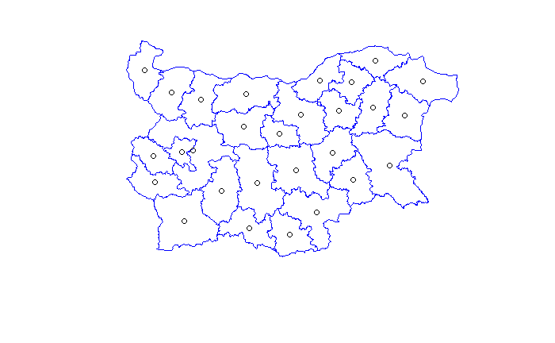

```r
# Spatial neighbors
coords <- st_centroid(st_geometry(bulgaria))
plot(st_geometry(bulgaria), border="blue")
plot(coords, add = TRUE)
```

## Defining neighbors

#### 1.KNN

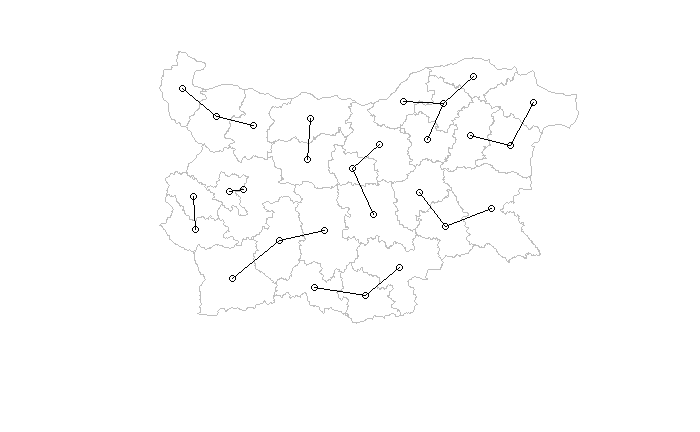

```r
knn1BG <- knn2nb(knearneigh(coords,k=1))
plot(st_geometry(bulgaria), border="grey")
plot(knn1BG, coords, add=TRUE)
```

#### 2.Critical cut-off neighborhood

```r
#minimum threshold distance
knn1IT <- knn2nb(knearneigh(coords,k=1))
all.linkedT <- max(unlist(nbdists(knn1IT, coords)))
all.linkedT
```

```
[1] 74.55625
```

```r
dnb75 <- dnearneigh(coords, 0, 75); dnb75
```

```
Neighbour list object:
Number of regions: 28
Number of nonzero links: 72
Percentage nonzero weights: 9.183673
Average number of links: 2.571429
```

```r
dnb100 <- dnearneigh(coords, 0, 100); dnb100
```

```
Neighbour list object:
Number of regions: 28
Number of nonzero links: 144
Percentage nonzero weights: 18.36735
Average number of links: 5.142857
```

```r
plot(st_geometry(bulgaria), border="grey")
plot(dnb75, coords, add=TRUE, col="blue")
```

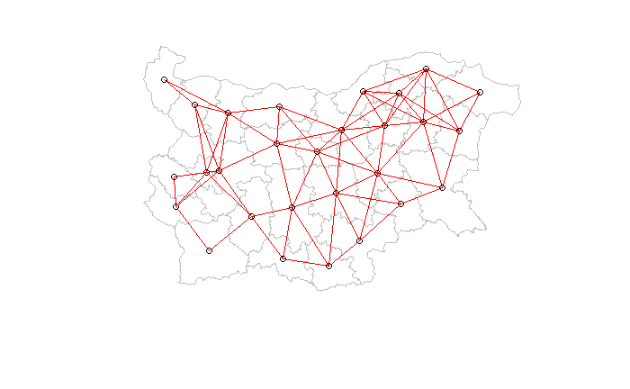

```r
plot(dnb100, coords, add=TRUE, col="red")
```

#### 3.Contiguity-based neighbourhood

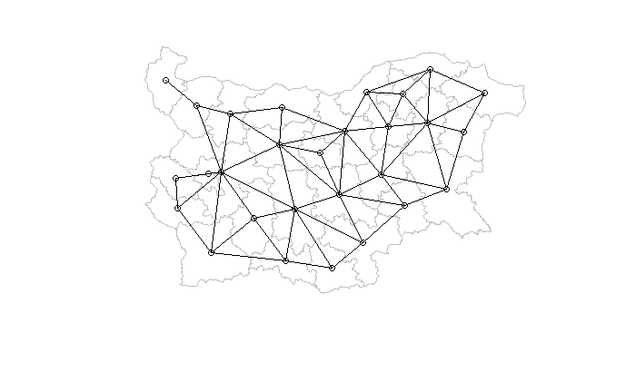

### Defining spatial weights

```r
dnb75.listw <- nb2listw(dnb75,style="W") #form of a list
dnb100.listw <- nb2listw(dnb100,style="W")
listw2mat(dnb75.listw)
```

```
        [,1] [,2] [,3] [,4]      [,5]      [,6] [,7] [,8] [,9] [,10]     [,11] [,12]
1  0.0000000  0.0  0.0 0.00 0.0000000 0.0000000  0.0 0.00  0.0   0.0 0.0000000   0.0
2  0.0000000  0.0  0.0 0.00 0.0000000 0.0000000  0.0 0.00  0.0   0.0 0.0000000   0.0
3  0.0000000  0.0  0.0 0.00 0.0000000 0.0000000  0.0 1.00  0.0   0.0 0.0000000   0.0
4  0.0000000  0.0  0.0 0.00 0.0000000 0.0000000  0.0 0.25  0.0   0.0 0.2500000   0.0
5  0.0000000  0.0  0.0 0.00 0.0000000 0.0000000  0.5 0.00  0.0   0.0 0.0000000   0.0
6  0.0000000  0.0  0.0 0.00 0.0000000 0.0000000  0.0 0.00  0.0   0.0 0.3333333   0.0
7  0.0000000  0.0  0.0 0.00 0.5000000 0.0000000  0.0 0.00  0.0   0.0 0.0000000   0.5
8  0.0000000  0.0  0.5 0.50 0.0000000 0.0000000  0.0 0.00  0.0   0.0 0.0000000   0.0
9  0.0000000  0.0  0.0 0.00 0.0000000 0.0000000  0.0 0.00  0.0   1.0 0.0000000   0.0
10 0.0000000  0.0  0.0 0.00 0.0000000 0.0000000  0.0 0.00  0.5   0.0 0.0000000   0.5
11 0.0000000  0.0  0.0 0.20 0.0000000 0.2000000  0.0 0.00  0.0   0.0 0.0000000   0.0
12 0.0000000  0.0  0.0 0.00 0.0000000 0.0000000  0.5 0.00  0.0   0.5 0.0000000   0.0
13 0.0000000  0.0  0.0 0.00 0.0000000 0.0000000  0.0 0.00  0.0   0.0 0.0000000   0.0
14 0.3333333  0.0  0.0 0.00 0.0000000 0.0000000  0.0 0.00  0.0   0.0 0.0000000   0.0
```

[output cut: 72 more lines]

### Building free-form spatial weight matrices

```r
#weights as inverse functions of the distance among centroids
distM <- st_distance(coords)/1000
class(distM) <- "matrix" #distance matrix
distM
```

```
           [,1]      [,2]      [,3]      [,4]      [,5]      [,6]      [,7]      [,8]
 [1,]   0.00000 303.52345 365.62326 283.08689  84.99646 173.18902 117.65779 328.09735
 [2,] 303.52345   0.00000 138.46415  92.77764 232.11351 157.01498 245.93218  80.29131
 [3,] 365.62326 138.46415   0.00000  85.04377 281.39987 192.45237 268.87110  58.81637
 [4,] 283.08689  92.77764  85.04377   0.00000 200.08789 111.11991 194.70584  49.44165
 [5,]  84.99646 232.11351 281.39987 200.08789   0.00000  89.15651  50.55515 246.61943
 [6,] 173.18902 157.01498 192.45237 111.11991  89.15651   0.00000  89.42579 158.52641
 [7,] 117.65779 245.93218 268.87110 194.70584  50.55515  89.42579   0.00000 243.81978
 [8,] 328.09735  80.29131  58.81637  49.44165 246.61943 158.52641 243.81978   0.00000
 [9,] 142.48181 401.21482 420.62309 350.97531 173.30993 246.29665 157.27099 400.33594
[10,]  94.21970 351.84510 380.83647 307.13015 121.59828 199.26311 112.55416 356.08632
[11,] 231.37624 114.32799 134.68884  52.14532 147.99825  58.97463 144.20083 100.08348
[12,]  78.09283 306.16644 337.61825 262.33763  77.27548 153.70083  68.77139 311.07498
[13,] 110.06513 330.17683 424.81352 339.79669 171.28241 242.68345 216.92689 376.96273
[14,]  62.31345 364.77698 427.15791 345.10587 145.80615 234.74714 170.72821 390.36840
```

[output cut: 110 more lines]

```r
# Three possible weight matrices
#using inverse functions of the matrices
W1 <- 1/(1+distM); diag(W1) <- 0
W2 <- 1/(1+distM^2); diag(W2) <- 0
W3 <- exp(0.1*-distM);diag(W3) <- 0

#Row-standardize them
W1s <- W1/rowSums(W1)
W2s <- W2/rowSums(W2)
W3s <- W3/rowSums(W3)
#convert
listW1s <- mat2listw(W1s)
listW2s <- mat2listw(W2s)
listW3s <- mat2listw(W3s)
```

# The Moran’s I test of spatial autocorrelation

(a global measure)

First, let’s merge data from the Bulgarian Statistical Institute as well.

```r
library(readxl)
bgstats <- read_excel("C:\\Users\\User\\Documents\\UNITN\\Geospatial\\For_GITHUB_project\\R_SpatialRegression\\BG_statistics.xlsx")
colnames(bgstats)[1] = "NAME_LATN"
prov <- merge(bulgaria, bgstats, by="NAME_LATN")
head(prov)
```

```
Simple feature collection with 6 features and 15 fields
Geometry type: MULTIPOLYGON
Dimension:     XY
Bounding box:  xmin: 22.86407 ymin: 41.23581 xmax: 28.60746 ymax: 44.00827
Geodetic CRS:  WGS 84
    NAME_LATN   NUTS_NAME Pop_2019 Pop_city Pop_villag Area precipitation_average
1 Blagoevgrad Благоевград   302694   182137     120557 6450              48.48020
2      Burgas      Бургас   409265   313132      96133 7752              47.58953
3     Dobrich      Добрич   171809   118492      53317 4719              41.55063
4     Gabrovo     Габрово   106598    87265      19333 2023              52.56989
5     Haskovo     Хасково   225317   162659      62658 5532              48.73795
6   Kardzhali    Кърджали   158204    63856      94348 3211              50.82483
  temperature_average wind_speed_average waterused PublicWaterSupply
1            8.723247           2.613756       113             99.65
2           11.841585           2.929849       108             99.94
```

[output cut: 18 more lines]

Below are some plots of several variables.

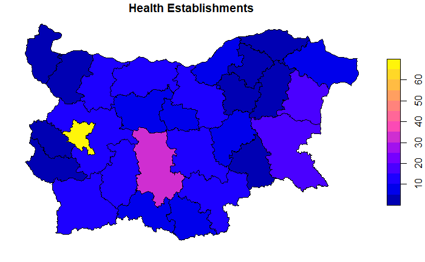

```r
plot(prov[c("HealthEstablishments")], main="Health Establishments")
```

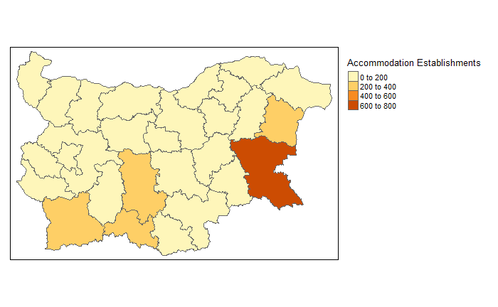

```r
tm_shape(prov) +
  tm_polygons("AccommodationEstablishments", title = "Accommodation Establishments") +
  tm_layout(legend.outside = TRUE)
```

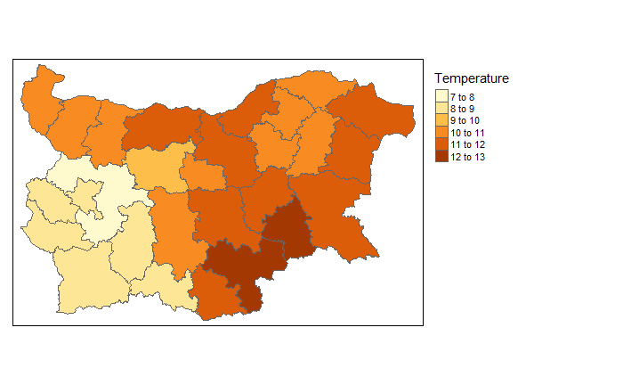

```r
tm_shape(prov) +
  tm_polygons("temperature_average", title = "Temperature") +
  tm_layout(legend.outside = TRUE)
```

```r
require(RColorBrewer)
qpal <- colorQuantile("OrRd", prov$GDPmlnbg, n=9)
leaflet(prov) %>%
  addPolygons(stroke = FALSE, fillOpacity = .8, smoothFactor = 0.2, color = ~qpal(GDPmlnbg)) %>%
  addTiles()
```

[interactive chart not shown]

```r
NA
```

## Moran’s test

Trying different variables, but it appears that p-values are quite high, so it seems that Spatial autocorrelation of the variables is not statistically significant.

```r
# GDP
moran.mc(prov$GDPmlnbg, dnb75.listw, nsim = 999)
```

```
    Monte-Carlo simulation of Moran I

data:  prov$GDPmlnbg
weights: dnb75.listw
number of simulations + 1: 1000

statistic = -0.00014423, observed rank = 793, p-value = 0.207
alternative hypothesis: greater
```

```r
#Temperature, try a different matrix
moran.test(prov$temperature_average, dnb100.listw, randomisation = TRUE)
```

```
    Moran I test under randomisation

data:  prov$temperature_average
weights: dnb100.listw

Moran I statistic standard deviate = -1.2059, p-value = 0.8861
alternative hypothesis: greater
sample estimates:
Moran I statistic       Expectation          Variance
      -0.17265214       -0.03703704        0.01264722
```

```r
moran.mc(prov$temperature_average, listW1s, nsim=999)
```

```
    Monte-Carlo simulation of Moran I

data:  prov$temperature_average
weights: listW1s
number of simulations + 1: 1000

statistic = -0.042736, observed rank = 463, p-value = 0.537
alternative hypothesis: greater
```

```r
moran.test(prov$precipitation_average, dnb100.listw, randomisation = TRUE)
```

```
    Moran I test under randomisation

data:  prov$precipitation_average
weights: dnb100.listw

Moran I statistic standard deviate = -0.51465, p-value = 0.6966
alternative hypothesis: greater
sample estimates:
Moran I statistic       Expectation          Variance
      -0.09341955       -0.03703704        0.01200224
```

```r
moran.mc(prov$precipitation_average, listW1s, nsim=999)
```

```
    Monte-Carlo simulation of Moran I

data:  prov$precipitation_average
weights: listW1s
number of simulations + 1: 1000

statistic = -0.054268, observed rank = 314, p-value = 0.686
alternative hypothesis: greater
```

```r
moran.test(prov$GeneratedMunicipalWaste, dnb100.listw, randomisation = TRUE)
```

```
    Moran I test under randomisation

data:  prov$GeneratedMunicipalWaste
weights: dnb100.listw

Moran I statistic standard deviate = -0.34658, p-value = 0.6355
alternative hypothesis: greater
sample estimates:
Moran I statistic       Expectation          Variance
     -0.062065237      -0.037037037       0.005215014
```

```r
moran.mc(prov$GeneratedMunicipalWaste, listW1s, nsim=999)
```

```
    Monte-Carlo simulation of Moran I

data:  prov$GeneratedMunicipalWaste
weights: listW1s
number of simulations + 1: 1000

statistic = -0.043815, observed rank = 451, p-value = 0.549
alternative hypothesis: greater
```

```r
moran.mc(prov$wind_speed_average, listW1s, nsim=999)
```

```
    Monte-Carlo simulation of Moran I

data:  prov$wind_speed_average
weights: listW1s
number of simulations + 1: 1000

statistic = -0.0092486, observed rank = 828, p-value = 0.172
alternative hypothesis: greater
```

### The Moran’s I test of spatial autocorrelation in OLS residuals of a linear regression model

```r
Lm1 <- lm(temperature_average ~ precipitation_average + wind_speed_average, prov)
summary(Lm1)

#plot of the studentized residuals
prov$studres <- rstudent(Lm1)
qpal <- colorQuantile("OrRd", prov$studres, n=4)
leaflet(prov) %>%
  addPolygons(stroke = FALSE, fillOpacity = .8, smoothFactor = 0.2, color = ~qpal(studres)) %>%
  addTiles()

#There can be seen some similarities in the residuals in some regions which are close next to each other.
```

[output not shown]

```r
#Applying the Moran's I test in the OLS residuals
lm.morantest(Lm1,dnb100.listw,resfun=rstudent)
```

```
    Global Moran I for regression residuals

data:
model: lm(formula = temperature_average ~ precipitation_average +
wind_speed_average, data = prov)
weights: dnb100.listw

Moran I statistic standard deviate = 0.10416, p-value = 0.4585
alternative hypothesis: greater
sample estimates:
Observed Moran I      Expectation         Variance
     -0.02572142      -0.03737117       0.01250909
```

```r
lm.morantest(Lm1,listW1s,resfun=rstudent)
```

```
    Global Moran I for regression residuals

data:
model: lm(formula = temperature_average ~ precipitation_average +
wind_speed_average, data = prov)
weights: listW1s

Moran I statistic standard deviate = 1.1868, p-value = 0.1177
alternative hypothesis: greater
sample estimates:
Observed Moran I      Expectation         Variance
     0.002569266     -0.037039875      0.001113963
```

Again not really significant even though a bit lower p-values.

```r
library(boot)
Lm1.lmx <- lm(temperature_average ~ precipitation_average + wind_speed_average, data = prov, x = TRUE)
MoraneI.boot <- function(var, i, ...) {
  var <- var[i]
  lmres <- lm(var ~ Lm1.lmx$x - 1)
  return(moran(x=residuals(lmres), ...)$I)
}
boot1 <- boot(residuals(Lm1.lmx),statistic=MoraneI.boot,
                R=999, sim="permutation", listw=listW1s,
                n=length(listW1s$neighbours), S0=Szero(listW1s))
ti <- (boot1$t0 - mean(boot1$t))/sqrt(var(boot1$t))
boot1
```

```
DATA PERMUTATION


Call:
boot(data = residuals(Lm1.lmx), statistic = MoraneI.boot, R = 999,
    sim = "permutation", listw = listW1s, n = length(listW1s$neighbours),
    S0 = Szero(listW1s))


Bootstrap Statistics :
        original     bias    std. error
t1* 0.0004070047 -0.0380637  0.03273351
```

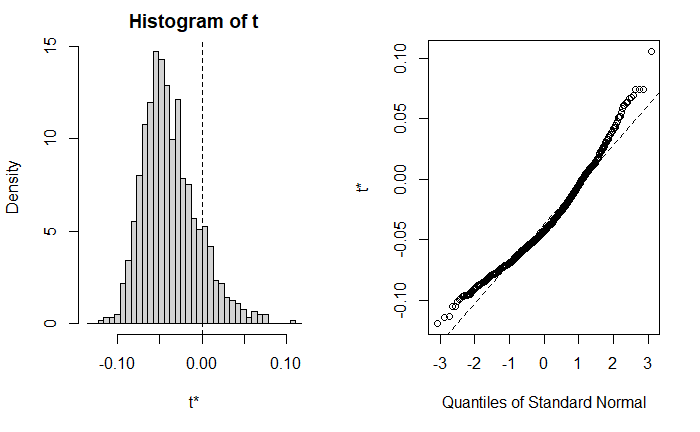

```r
plot(boot1)
```

```r
# We can see there is some pattern in the residuals, they don't follow the quantiles
```

# Local Moran I and test

(local spatial clusters)

## 1. Moran scatterplot

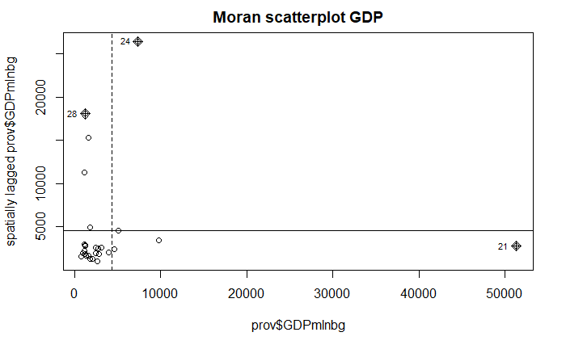

```r
#GDP
mplot <- moran.plot(prov$GDPmlnbg, listw=dnb75.listw, main="Moran scatterplot GDP")
```

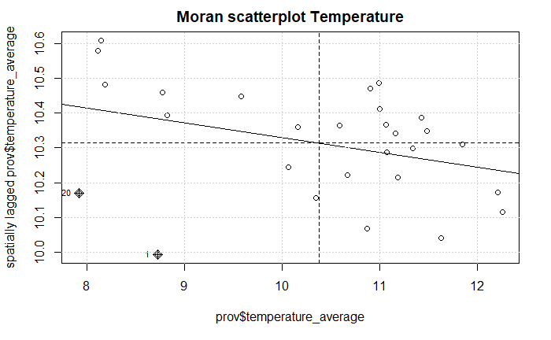

```r
# Since the pattern of Sofia is particular it is way far off, it is difficult to make inference

mplot <- moran.plot(prov$temperature_average, listw=listW1s, main="Moran scatterplot Temperature")
grid()
```

```r
# There seem to be some division in the four quadrants;
# higher average temperature seems to be  associated with kind of lower local average
# Sofia and Blagoevgrad exert the most influence on the regression line
```

From the plot some things could be pointed out: There seem to be some division in the four quadrants; Higher temperature seems to be associated with lower local average. Sofia and Blagoevgrad exert the most influence on the regression line.

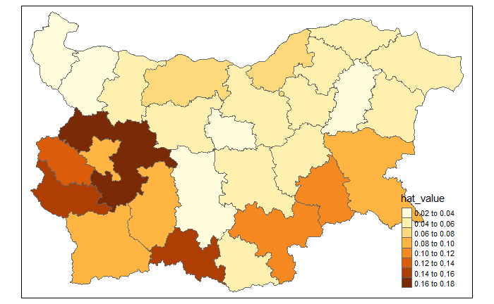

Below, the most influencial units.

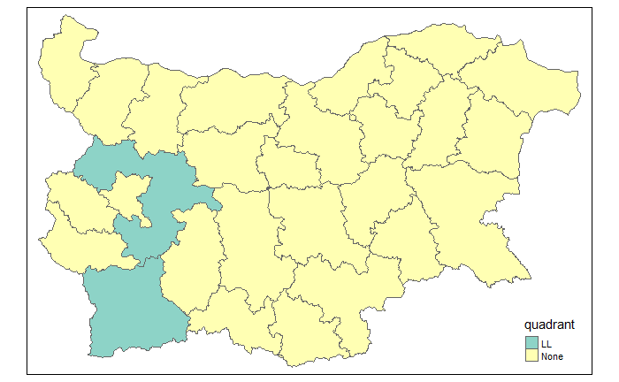

# 2. The Local Moran’s I values

```r
lmI <- localmoran(prov$temperature_average, listW1s)
head(lmI)
```

```
           Ii         E.Ii      Var.Ii        Z.Ii Pr(z != E(Ii))
1  0.37390121 -0.060194827 0.073565393  1.60047556      0.1094931
2 -0.05588626 -0.047669595 0.015177602 -0.06669513      0.9468244
3 -0.03556797 -0.010797088 0.005430731 -0.33613392      0.7367699
4  0.02408043 -0.002130174 0.001081662  0.79695037      0.4254799
5 -0.22103878 -0.074394573 0.017216213 -1.11762501      0.2637272
6 -0.04251241 -0.020362472 0.006240486 -0.28039054      0.7791779
```

```
Variable(s) "lmI" contains positive and negative values, so midpoint is set to 0. Set midpoint = NA to show the full spectrum of the color palette.
```

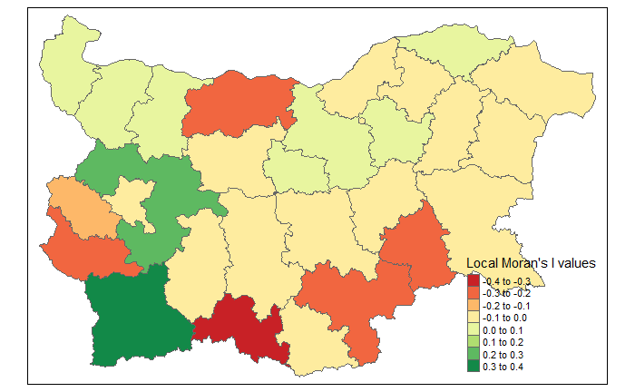

```r
prov$lmI <- lmI[,1]
tm_shape(prov) +
    tm_polygons("lmI", title = "Local Moran's I values")
```

```r
# We can see some of the local regions that are being identified
```

```r
lmIp1 <- localmoran_perm(prov$temperature_average, listW1s, nsim = 9999, iseed = 1)
lmIp2 <- localmoran_perm(prov$GDPmlnbg, listW1s, nsim = 9999, iseed = 1)

#Things do not seem significant.
```

[output not shown]

# Spatial regression

Let’s see if there exists the need to include spatial characteristics when computing models.

```r
library(spatialreg)
```

```r
#The Lagrange multiplier (LM) test of spatial dependence on OLS residuals

Lm1 <- lm(temperature_average ~ precipitation_average + wind_speed_average, prov)
natOLSlmTests <- lm.LMtests(Lm1, dnb100.listw,
                    test=c("LMerr", "LMlag", "RLMerr", "RLMlag"))
summary(natOLSlmTests)
```

```
    Lagrange multiplier diagnostics for spatial dependence
data:
model: lm(formula = temperature_average ~ precipitation_average +
wind_speed_average, data = prov)
weights: dnb100.listw

       statistic parameter p.value
LMerr   0.059965         1  0.8066
LMlag   1.000447         1  0.3172
RLMerr  0.874187         1  0.3498
RLMlag  1.814669         1  0.1779
```

After having tried with different weight matrices, it seems there is no presence of importance of the spatial distribution for the model about average temperature.

```r
summary(natOLSlmTests)
```

[output not shown]

From the analysis conducted, it appears that overall in Bulgarian districts, the geographical location does not play a big role for some statistical indicators. The local/global effects cannot be seen, and in fact since the main and most developed cities of the country are more or less scattered around the country, it makes sense.

Therefore, if regression is to be done on some factor concerning the variables at hand, it can be relied on linear regression models with OLS estimator.

There could be some other indicator variables for the country, which could possibly possess the need to be analysed with the use of a spatial regression model.

In fact, maybe if analysis is done based on municipalities, some more useful and informative results could be obtained. However, not much data of this kind is available.